# Logistic Regression in R

Ryan Gallagher

2025-02-27

## 1. Introduction

This document provides a walkthrough for fitting **Logistic Regression**, **Multiple Logistic Regression**, and **Multinomial Logistic Regression** in R using the `glm()` function and `nnet` package.

## 2. Load Required Libraries

```r
library(ggplot2)
library(nnet)  # For multinomial logistic regression
library(dplyr)
library(ISLR2)
```

## 3. Exploratory Data Analysis with ggplot2

### 3.1 Load Data

We use the `Default` dataset from the `ISLR2` package.

```r
data <- Default
str(data)
```

```
## 'data.frame':    10000 obs. of  4 variables:
##  $ default: Factor w/ 2 levels "No","Yes": 1 1 1 1 1 1 1 1 1 1 ...
##  $ student: Factor w/ 2 levels "No","Yes": 1 2 1 1 1 2 1 2 1 1 ...
##  $ balance: num  730 817 1074 529 786 ...
##  $ income : num  44362 12106 31767 35704 38463 ...
```

### 3.2 Visualizing the Data

#### Distribution of Balance

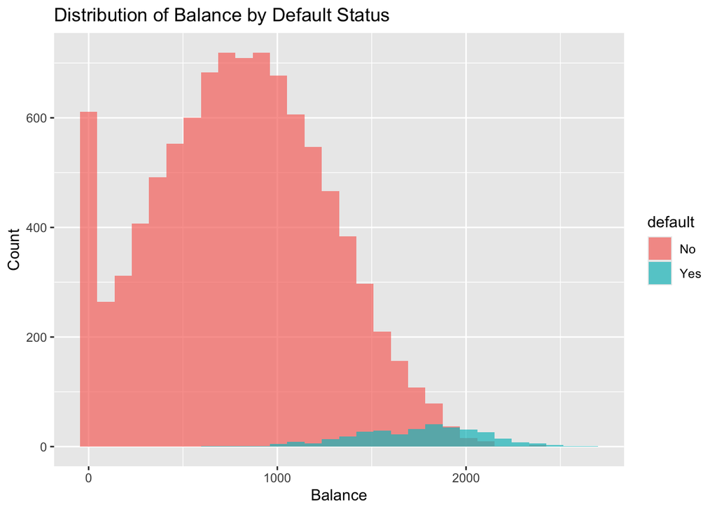

```r
ggplot(data, aes(x = balance, fill = default)) +
  geom_histogram(bins = 30, alpha = 0.7, position = "identity") +
  labs(title = "Distribution of Balance by Default Status", x = "Balance", y = "Count")
```

#### Distribution of Income

This appears to be **bimodal** - i.e. two normal distributions packaged as one.

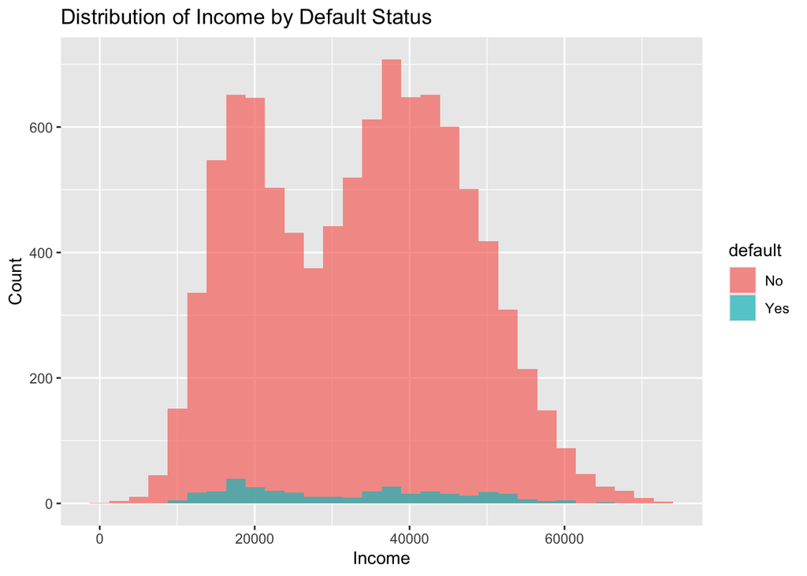

```r
ggplot(data, aes(x = income, fill = default)) +
  geom_histogram(bins = 30, alpha = 0.7, position = "identity") +
  labs(title = "Distribution of Income by Default Status", x = "Income", y = "Count")
```

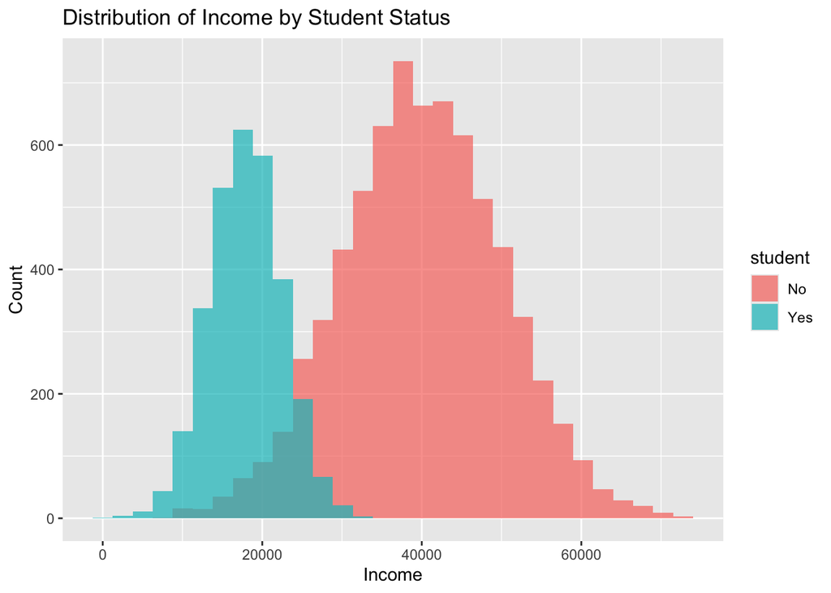

```r
ggplot(data, aes(x = income, fill = student)) +
  geom_histogram(bins = 30, alpha = 0.7, position = "identity") +
  labs(title = "Distribution of Income by Student Status", x = "Income", y = "Count")
```

#### Student Status and Default

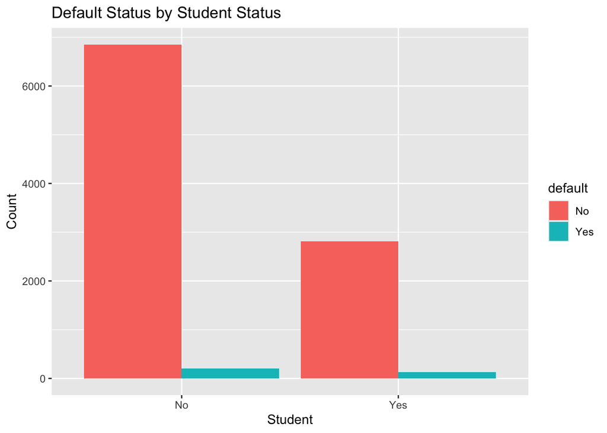

```r
ggplot(data, aes(x = student, fill = default)) +
  geom_bar(position = "dodge") +
  labs(title = "Default Status by Student Status", x = "Student", y = "Count")
```

## 4. Logistic Regression (Binary Outcome)

### 4.1 Fit Logistic Regression Model

```r
logit_model <- glm(default ~ balance, data = data, family = binomial)
summary(logit_model)
```

```
##
## Call:
## glm(formula = default ~ balance, family = binomial, data = data)
##
## Coefficients:
##               Estimate Std. Error z value Pr(>|z|)
## (Intercept) -1.065e+01  3.612e-01  -29.49   <2e-16 ***
## balance      5.499e-03  2.204e-04   24.95   <2e-16 ***
## ---
## Signif. codes:  0 '***' 0.001 '**' 0.01 '*' 0.05 '.' 0.1 ' ' 1
##
## (Dispersion parameter for binomial family taken to be 1)
##
##     Null deviance: 2920.6  on 9999  degrees of freedom
## Residual deviance: 1596.5  on 9998  degrees of freedom
## AIC: 1600.5
##
## Number of Fisher Scoring iterations: 8
```

### 4.2 Make Predictions

```r
data$predicted_prob <- predict(logit_model, type = "response")
head(data)
```

```
##   default student   balance    income predicted_prob
## 1      No      No  729.5265 44361.625   0.0013056797
## 2      No     Yes  817.1804 12106.135   0.0021125949
## 3      No      No 1073.5492 31767.139   0.0085947405
## 4      No      No  529.2506 35704.494   0.0004344368
## 5      No      No  785.6559 38463.496   0.0017769574
## 6      No     Yes  919.5885  7491.559   0.0037041528
```

### 4.3 Evaluate Model Performance

```r
threshold <- 0.5
data$predicted_class <- ifelse(data$predicted_prob > threshold, "Yes", "No")
conf_matrix <- table(data$predicted_class, data$default)
conf_matrix
```

```
##
##         No  Yes
##   No  9625  233
##   Yes   42  100
```

```r
accuracy <- sum(diag(conf_matrix)) / sum(conf_matrix)
accuracy
```

```
## [1] 0.9725
```

## 5. Multiple Logistic Regression

### 5.1 Fit Model with Multiple Predictors (Including Interaction Term)

Including an **interaction term** between `income` and `student` allows the effect of income on default probability to differ between students and non-students. This accounts for the bimodal nature of income distribution and ensures that the influence of income is properly modeled for each group.

```r
logit_mult_model <- glm(default ~ balance + income * student, data = data, family = binomial)
summary(logit_mult_model)
```

```
##
## Call:
## glm(formula = default ~ balance + income * student, family = binomial,
##     data = data)
##
## Coefficients:
##                     Estimate Std. Error z value Pr(>|z|)
## (Intercept)       -1.081e+01  5.031e-01 -21.495   <2e-16 ***
## balance            5.737e-03  2.319e-04  24.736   <2e-16 ***
## income             1.644e-06  8.633e-06   0.190    0.849
## studentYes        -9.343e-01  6.067e-01  -1.540    0.124
## income:studentYes  1.429e-05  2.772e-05   0.516    0.606
## ---
## Signif. codes:  0 '***' 0.001 '**' 0.01 '*' 0.05 '.' 0.1 ' ' 1
##
## (Dispersion parameter for binomial family taken to be 1)
##
##     Null deviance: 2920.6  on 9999  degrees of freedom
## Residual deviance: 1571.3  on 9995  degrees of freedom
## AIC: 1581.3
##
## Number of Fisher Scoring iterations: 8
```

### 5.2 Make Predictions & Evaluate

```r
data$mult_predicted_prob <- predict(logit_mult_model, type = "response")
data$mult_predicted_class <- ifelse(data$mult_predicted_prob > threshold, "Yes", "No")
conf_matrix_mult <- table(data$mult_predicted_class, data$default)
conf_matrix_mult
```

```
##
##         No  Yes
##   No  9628  227
##   Yes   39  106
```

```r
accuracy_mult <- sum(diag(conf_matrix_mult)) / sum(conf_matrix_mult)
accuracy_mult
```

```
## [1] 0.9734
```

### 5.3 Alternative Approach: Transform Income

Applying a **log transformation** to income can help address the bimodal nature by making the distribution more normal.

```r
data$log_income <- log(data$income)
logit_transformed_model <- glm(default ~ balance + log_income + student, data = data, family = binomial)
summary(logit_transformed_model)
```

```
##
## Call:
## glm(formula = default ~ balance + log_income + student, family = binomial,
##     data = data)
##
## Coefficients:
##               Estimate Std. Error z value Pr(>|z|)
## (Intercept) -1.201e+01  2.746e+00  -4.376 1.21e-05 ***
## balance      5.736e-03  2.319e-04  24.733  < 2e-16 ***
## log_income   1.200e-01  2.578e-01   0.465   0.6417
## studentYes  -6.172e-01  2.564e-01  -2.408   0.0161 *
## ---
## Signif. codes:  0 '***' 0.001 '**' 0.01 '*' 0.05 '.' 0.1 ' ' 1
##
## (Dispersion parameter for binomial family taken to be 1)
##
##     Null deviance: 2920.6  on 9999  degrees of freedom
## Residual deviance: 1571.5  on 9996  degrees of freedom
## AIC: 1579.5
##
## Number of Fisher Scoring iterations: 8
```

### 5.4 Fit Separate Models for Students and Non-Students

Since the `income` variable behaves differently for students and non-students, running **two separate logistic regression models** makes sense. This allows us to fit more appropriate relationships between predictors and default within each group, rather than forcing a single model to account for both distributions.

```r
logit_student <- glm(default ~ balance + income, data = filter(data, student == "Yes"), family = binomial)
logit_nonstudent <- glm(default ~ balance + income, data = filter(data, student == "No"), family = binomial)
summary(logit_student)
```

```
##
## Call:
## glm(formula = default ~ balance + income, family = binomial,
##     data = filter(data, student == "Yes"))
##
## Coefficients:
##               Estimate Std. Error z value Pr(>|z|)
## (Intercept) -1.151e+01  8.107e-01 -14.194   <2e-16 ***
## balance      5.598e-03  3.774e-04  14.832   <2e-16 ***
## income       1.585e-05  2.610e-05   0.607    0.544
## ---
## Signif. codes:  0 '***' 0.001 '**' 0.01 '*' 0.05 '.' 0.1 ' ' 1
##
## (Dispersion parameter for binomial family taken to be 1)
##
##     Null deviance: 1046.85  on 2943  degrees of freedom
## Residual deviance:  563.03  on 2941  degrees of freedom
## AIC: 569.03
##
## Number of Fisher Scoring iterations: 8
```

```r
summary(logit_nonstudent)
```

```
##
## Call:
## glm(formula = default ~ balance + income, family = binomial,
##     data = filter(data, student == "No"))
##
## Coefficients:
##               Estimate Std. Error z value Pr(>|z|)
## (Intercept) -1.094e+01  5.752e-01 -19.015   <2e-16 ***
## balance      5.818e-03  2.938e-04  19.803   <2e-16 ***
## income       1.597e-06  8.670e-06   0.184    0.854
## ---
## Signif. codes:  0 '***' 0.001 '**' 0.01 '*' 0.05 '.' 0.1 ' ' 1
##
## (Dispersion parameter for binomial family taken to be 1)
##
##     Null deviance: 1861.8  on 7055  degrees of freedom
## Residual deviance: 1008.0  on 7053  degrees of freedom
## AIC: 1014
##
## Number of Fisher Scoring iterations: 8
```

## 6. Multinomial Logistic Regression

### 6.1 Load Data

We use the `Carseats` dataset from the `ISLR2` package and create a categorical outcome variable.

```r
data <- Carseats
data$SalesCategory <- cut(data$Sales, breaks = 3, labels = c("Low", "Medium", "High"))
```

### 6.2 Fit Multinomial Logistic Regression

```r
multi_model <- multinom(SalesCategory ~ Price + Income + Advertising, data = data)
summary(multi_model)
```

```
## Call:
## multinom(formula = SalesCategory ~ Price + Income + Advertising,
##     data = data)
##
## Coefficients:
##        (Intercept)       Price      Income Advertising
## Medium    3.645096 -0.02909122 0.004288951   0.0834958
## High      4.839031 -0.06414212 0.011164722   0.1417921
##
## Std. Errors:
##        (Intercept)       Price      Income Advertising
## Medium   0.7937487 0.006004112 0.004488935  0.02137942
## High     1.1240727 0.009264365 0.006892574  0.03025054
##
## Residual Deviance: 640.794
## AIC: 656.794
```

### 6.3 Make Predictions

```r
data$multi_predicted_class <- predict(multi_model)
head(data)
```

```
##   Sales CompPrice Income Advertising Population Price ShelveLoc Age Education
## 1  9.50       138     73          11        276   120       Bad  42        17
## 2 11.22       111     48          16        260    83      Good  65        10
## 3 10.06       113     35          10        269    80    Medium  59        12
## 4  7.40       117    100           4        466    97    Medium  55        14
## 5  4.15       141     64           3        340   128       Bad  38        13
## 6 10.81       124    113          13        501    72       Bad  78        16
##   Urban  US SalesCategory multi_predicted_class
## 1   Yes Yes        Medium                Medium
## 2   Yes Yes          High                Medium
## 3   Yes Yes        Medium                Medium
## 4   Yes Yes        Medium                Medium
## 5   Yes  No           Low                Medium
## 6    No Yes        Medium                  High
```

### 6.4 Evaluate Model

```r
conf_matrix_multi <- table(data$multi_predicted_class, data$SalesCategory)
conf_matrix_multi
```

```
##
##          Low Medium High
##   Low     25     17    0
##   Medium  77    224   48
##   High     0      6    3
```

```r
accuracy_multi <- sum(diag(conf_matrix_multi)) / sum(conf_matrix_multi)
accuracy_multi
```

```
## [1] 0.63
```